# Statystyki opisowe baz danych Customers, Articles, Transaction.

#### Na początek zaimportujmy niezbędne pakiety.

```python
import numpy as np # do obliczen
import pandas as pd # do ptrzetwarzania danych
import seaborn as sns # do wizualizacji danych
import matplotlib.pyplot as plt # basic visualisation library
import datetime as dt # library to opearate on dates
art=pd.read_csv("C:/STUDIA III/articles.csv/articles.csv")

cust=pd.read_csv("C:/STUDIA III/customers.csv//customers.csv")

trans=pd.read_csv("C:/STUDIA III/transactions_train.csv/transactions_train.csv")
```

## Baza danych Articles - krótka analiza

### Ta baza danych zawiera informacje o asortymencie sklepów H&M.

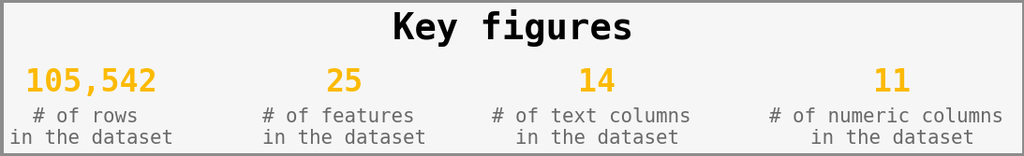

```python
import matplotlib as mpl
mpl.rcParams.update(mpl.rcParamsDefault)

data = art
art_dtypes = art.dtypes.value_counts()

fig = plt.figure(figsize=(5,2),facecolor='white')

ax0 = fig.add_subplot(1,1,1)
font = 'monospace'
ax0.text(1, 0.8, "Key figures",color='black',fontsize=28, fontweight='bold', fontfamily=font, ha='center')

ax0.text(0, 0.4, "{:,d}".format(data.shape[0]), color='#fcba03', fontsize=24, fontweight='bold', fontfamily=font, ha='center')
ax0.text(0, 0.001, "# of rows \nin the dataset",color='dimgrey',fontsize=15, fontweight='light', fontfamily=font,ha='center')

ax0.text(0.6, 0.4, "{}".format(data.shape[1]), color='#fcba03', fontsize=24, fontweight='bold', fontfamily=font, ha='center')
ax0.text(0.6, 0.001, "# of features \nin the dataset",color='dimgrey',fontsize=15, fontweight='light', fontfamily=font,ha='center')

ax0.text(1.2, 0.4, "{}".format(art_dtypes[0]), color='#fcba03', fontsize=24, fontweight='bold', fontfamily=font, ha='center')
ax0.text(1.2, 0.001, "# of text columns \nin the dataset",color='dimgrey',fontsize=15, fontweight='light', fontfamily=font, ha='center')

ax0.text(1.9, 0.4,"{}".format(art_dtypes[1]), color='#fcba03', fontsize=24, fontweight='bold', fontfamily=font, ha='center')
ax0.text(1.9, 0.001,"# of numeric columns \nin the dataset",color='dimgrey',fontsize=15, fontweight='light', fontfamily=font,ha='center')

ax0.set_yticklabels('')
ax0.tick_params(axis='y',length=0)
ax0.tick_params(axis='x',length=0)
ax0.set_xticklabels('')

for direction in ['top','right','left','bottom']:
    ax0.spines[direction].set_visible(False)

fig.subplots_adjust(top=0.9, bottom=0.2, left=0, hspace=1)

fig.patch.set_linewidth(5)
fig.patch.set_edgecolor('#8c8c8c')
fig.patch.set_facecolor('#f6f6f6')
ax0.set_facecolor('#f6f6f6')

plt.show()
```

### Można sprawdzić również, jakie ile mamy brakujących wartości:

```python
art.isna().sum()/len(art)*100
```

```
article_id                      0.000000
product_code                    0.000000
prod_name                       0.000000
product_type_no                 0.000000
product_type_name               0.000000
product_group_name              0.000000
graphical_appearance_no         0.000000
graphical_appearance_name       0.000000
colour_group_code               0.000000
colour_group_name               0.000000
perceived_colour_value_id       0.000000
perceived_colour_value_name     0.000000
perceived_colour_master_id      0.000000
perceived_colour_master_name    0.000000
department_no                   0.000000
department_name                 0.000000
index_code                      0.000000
index_name                      0.000000
index_group_no                  0.000000
index_group_name                0.000000
section_no                      0.000000
section_name                    0.000000
garment_group_no                0.000000
garment_group_name              0.000000
detail_desc                     0.394156
dtype: float64
```

### Jak widzimy, tylko w jednej kolumnie - detail desc - brakuje wartości, ale jest to bardzo niewielka część zbioru danych - około 0,4%.

### Przyjrzyjmy się teraz kolorom asortymentu H&M.

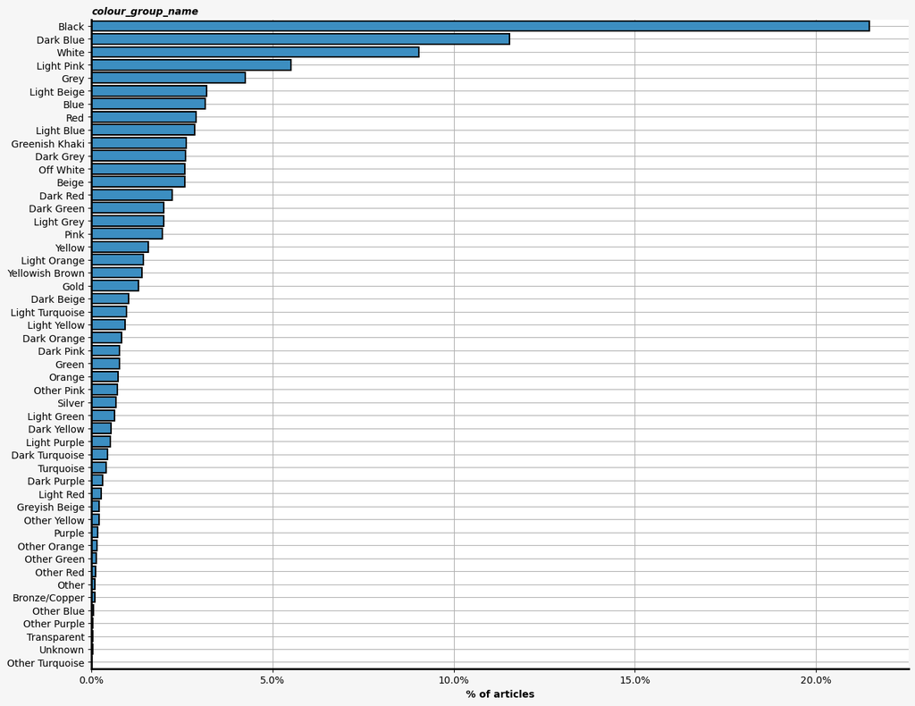

```python
import matplotlib.ticker as mtick

def plot_bar(database, col, figsize=(13,5), pct=False, label='articles'):
    fig, ax = plt.subplots(figsize=figsize, facecolor='#f6f6f6')
    for loc in ['bottom', 'left']:
        ax.spines[loc].set_visible(True)
        ax.spines[loc].set_linewidth(2)
        ax.spines[loc].set_color('black')
    ax.spines['right'].set_visible(False)
    ax.spines['top'].set_visible(False)

    if pct:
        data = database[col].value_counts()
        data = data.div(data.sum()).mul(100)
        data = data.reset_index()
        ax = sns.barplot(data=data, x=col, y='index', color='#2693d7', lw=1.5, ec='black', zorder=2)
        ax.set_xlabel('% of ' + label, fontsize=10, weight='bold')
        ax.xaxis.set_major_formatter(mtick.PercentFormatter())
    else:
        data = database[col].value_counts().reset_index()
        ax = sns.barplot(data=data, x=col, y='index', color='#2693d7', lw=1.5, ec='black', zorder=2)
        ax.set_xlabel('# of articles' + label)

    ax.grid(zorder=0)
    ax.text(0, -0.75, col, color='black', fontsize=10, ha='left', va='bottom', weight='bold', style='italic')
    ax.set_ylabel('')

    plt.show()
plot_bar(art, 'colour_group_name', figsize=(15,12), pct=True)
```

### Przyjrzyjmy się teraz rodzajom kolorów. Tutaj rozpatrujemy ogólne kategorie - Dark/Dusty Light/Light i td.

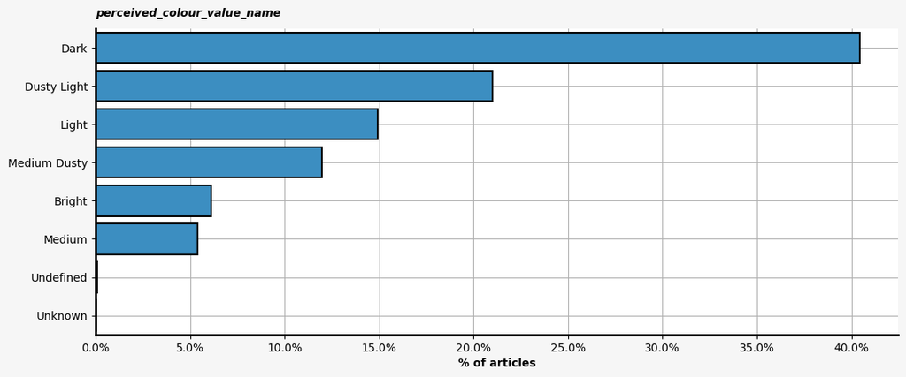

```python
plot_bar(art, 'perceived_colour_value_name', pct=True)
```

### Rodzaj koloru jest mniej więcej zgodny z samym kolorem, ale jest bardziej ogólny. Wyjaśnia to następujący wykres.

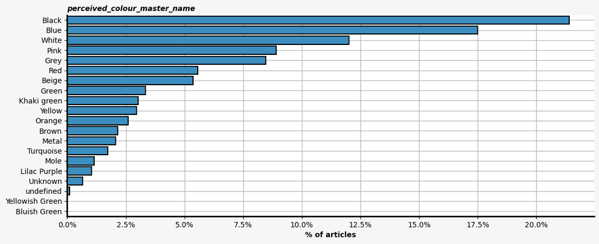

```python
plot_bar(art, 'perceived_colour_master_name', pct=True)
```

### Następny wykres dotyczy róznych rodzajów wzorów na artykułach.

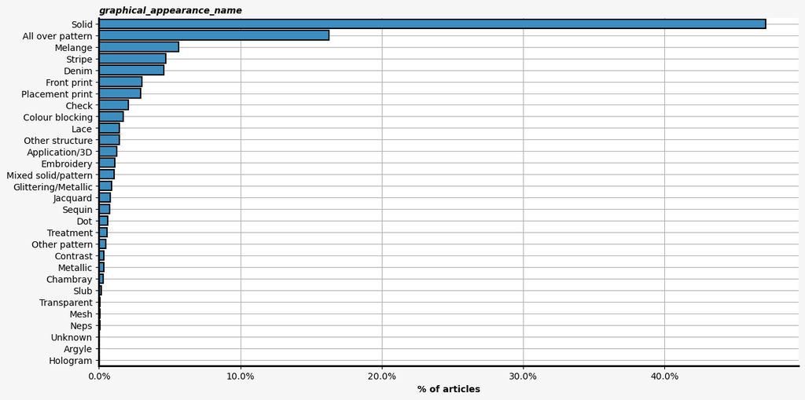

```python
plot_bar(art, 'graphical_appearance_name', figsize=(14,7), pct=True)
```

### Warto zobaczyć również jak wyglądają przykładowe opisy ubrań.

```python
art['detail_desc'].drop_duplicates().to_list()[:10]
```

```
['Jersey top with narrow shoulder straps.',
 'Microfibre T-shirt bra with underwired, moulded, lightly padded cups that shape the bust and provide good support. Narrow adjustable shoulder straps and a narrow hook-and-eye fastening at the back. Without visible seams for greater comfort.',
 'Semi shiny nylon stockings with a wide, reinforced trim at the top. Use with a suspender belt. 20 denier.',
 'Tights with built-in support to lift the bottom. Black in 30 denier and light amber in 15 denier.',
 'Semi shiny tights that shape the tummy, thighs and calves while also encouraging blood circulation in the legs. Elasticated waist.',
 'Opaque matt tights. 200 denier.',
 'Sweatshirt in soft organic cotton with a  press-stud on one shoulder (sizes 12-18 months and 18-24 months without a press-stud). Brushed inside.',
 'Two soft bandeau bras in soft jersey with side support and a silicone trim at the top.',
 'Fitted top in soft stretch jersey with a wide neckline and long sleeves.',
 'Trousers in sweatshirt fabric with an elasticated drawstring waist, side pockets, a back pocket and ribbed hems. Soft brushed inside.']
```

## Customers dataset, czyli baza danych klientów.

### Baza ta zawiera dane o klientach. Zbieranie tego typu danych pozwala firmie na ulepszenie systemu rekomendacji. Baza zawiera dane statyczne, takie jak wiek/ płeć i td. Przyjrzyjmy się temu, co przekazała nam firma H&M:

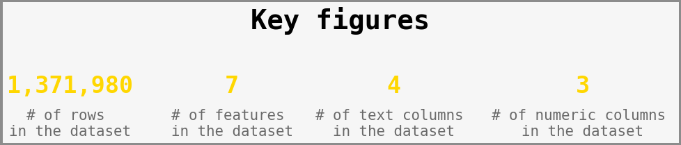

```python
mpl.rcParams.update(mpl.rcParamsDefault)

cust_dtypes = cust.dtypes.value_counts()
data = cust

fig = plt.figure(figsize=(5,2),facecolor='white')

ax0 = fig.add_subplot(1,1,1)
ax0.text(1.0, 1, "Key figures",color='black',fontsize=28, fontweight='bold', fontfamily='monospace',ha='center')

ax0.text(0, 0.4, "{:,d}".format(data.shape[0]), color='gold', fontsize=24, fontweight='bold', fontfamily='monospace', ha='center')
ax0.text(0, 0.001, "# of rows \nin the dataset",color='dimgrey',fontsize=15, fontweight='light', fontfamily='monospace',ha='center')

ax0.text(0.6, 0.4, "{}".format(data.shape[1]), color='gold', fontsize=24, fontweight='bold', fontfamily='monospace', ha='center')
ax0.text(0.6, 0.001, "# of features \nin the dataset",color='dimgrey',fontsize=15, fontweight='light', fontfamily='monospace',ha='center')

ax0.text(1.2, 0.4, "{}".format(cust_dtypes[0]), color='gold', fontsize=24, fontweight='bold', fontfamily='monospace', ha='center')
ax0.text(1.2, 0.001, "# of text columns \nin the dataset",color='dimgrey',fontsize=15, fontweight='light', fontfamily='monospace',ha='center')

ax0.text(1.9, 0.4,"{}".format(cust_dtypes[1]), color='gold', fontsize=24, fontweight='bold', fontfamily='monospace', ha='center')
ax0.text(1.9, 0.001,"# of numeric columns \nin the dataset",color='dimgrey',fontsize=15, fontweight='light', fontfamily='monospace',ha='center')

ax0.set_yticklabels('')
ax0.tick_params(axis='y',length=0)
ax0.tick_params(axis='x',length=0)
ax0.set_xticklabels('')

for direction in ['top','right','left','bottom']:
    ax0.spines[direction].set_visible(False)

fig.patch.set_linewidth(5)
fig.patch.set_edgecolor('#8c8c8c')
fig.patch.set_facecolor('#f6f6f6')
ax0.set_facecolor('#f6f6f6')

plt.show()
```

### Sprawdżmy, czy są braki danych:

```python
cust.isna().sum()
```

```
customer_id                    0
FN                        895050
Active                    907576
club_member_status          6062
fashion_news_frequency     16009
age                        15861
postal_code                    0
dtype: int64
```

### Na pierwszy rzut oka jest ich dużo, ale wynika to z tego, że niektóre kolumny takie jak FN i active przyjmują wartości 1 lub NaN. Zatem zmieniamy to na 0 i pozbywamy się owego problemu.

```python
cust_backup = cust.copy()
cust[['FN','Active']] = cust[['FN','Active']].fillna(0)
```

### Przyjrzyjmy się rozkładom FN i active.

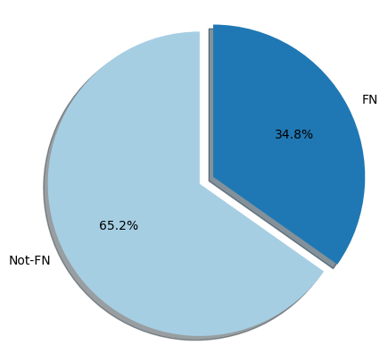

```python
fig, ax = plt.subplots(figsize=(5,5))
explode = (0, 0.1)
colors = sns.color_palette('Paired')
ax.pie(cust['FN'].value_counts(), explode=explode, labels=['Not-FN','FN'],
       autopct='%1.1f%%',shadow=True, startangle=90, colors=colors)
ax.axis('equal')
plt.show()
```

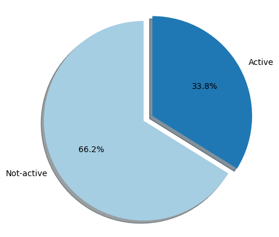

```python
fig, ax = plt.subplots(figsize=(5,5))
explode = (0, 0.1)
colors = sns.color_palette('Paired')
ax.pie(cust['Active'].value_counts(), explode=explode, labels=['Not-active','Active'],
       autopct='%1.1f%%',shadow=True, startangle=90, colors=colors)
ax.axis('equal')
plt.show()
```

```python
FN_Active = len(cust[(cust['FN']==1) & (cust['Active']==1)])/cust.shape[0]*100
print('Percentage of customers that have both FN and Active status: {}%'.format(round(FN_Active,2)))
```

```
Percentage of customers that have both FN and Active status: 33.85%
```

### Wygląda na to, że wszyscy klienci, którzy są aktywni, mają również status FN. Jednak nie jest to prawdą - nie wszyscy użytkownicy o statusie FN są aktywni. Sprawdźmy to przez podstawienie tych dwóch zestawów. Jeśli jest to prawda, spodziewalibyśmy się zobaczyć różnicę procentową rzędu 0,9%.

```python
FN_not_active = len(cust[(cust['FN']==1) & (cust['Active']!=1)])/cust.shape[0]*100
print('Percentage of customers that have FN status but are not Active: {}%'.format(round(FN_not_active,2)))
```

```
Percentage of customers that have FN status but are not Active: 0.91%
```

### Jak pamiętamy z analizy brakujących wartości, istnieje również grupa osób, o których nie mamy żadnych danych. Być może są to osoby, które w ogóle nie mają członkostwa - aby dodać je do wizualizacji, wypełnię NaN przez 'N/A'.

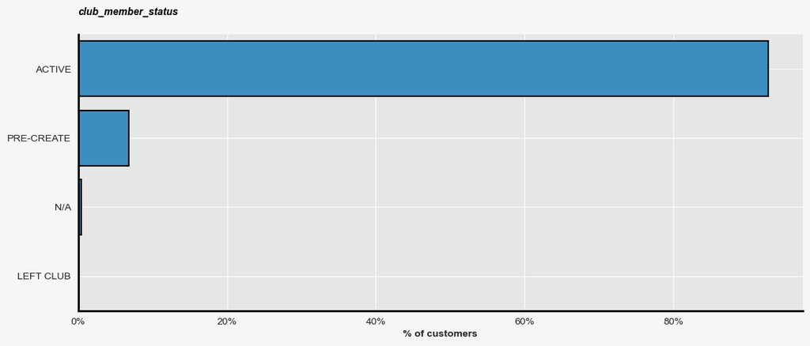

```python
cust['club_member_status'] = cust['club_member_status'].fillna('N/A')
sns.set_style("darkgrid", {"axes.facecolor": ".9"})
plot_bar(cust, 'club_member_status', pct=True, label='customers')
```

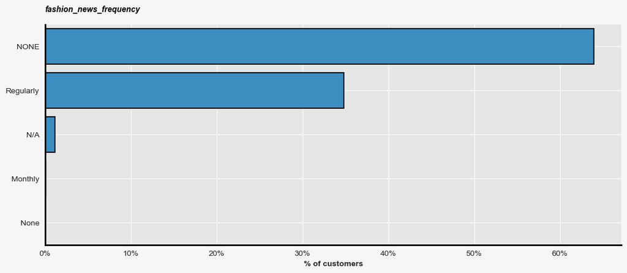

```python
cust['fashion_news_frequency'] = cust['fashion_news_frequency'].fillna('N/A')
plot_bar(cust, 'fashion_news_frequency', pct=True, label='customers')
```

### Widzimy tutaj, że istnieją dwa statusy, które można połączyć: N/A i None, aby poprawić jakość danych i zredukować jeden wymiar. Większość klientów nie otrzymuje żadnych informacji od firmy H&M.

### Zobaczmy teraz, jaki jest rozkład wieku.

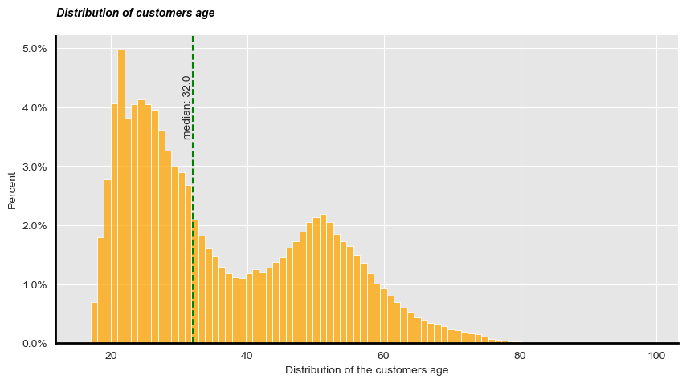

```python
fig, ax = plt.subplots(figsize=(10,5))
ax = sns.histplot(data=cust, x='age', bins=cust['age'].nunique(), color='orange', stat="percent")
ax.set_xlabel('Distribution of the customers age')
for loc in ['bottom', 'left']:
    ax.spines[loc].set_visible(True)
    ax.spines[loc].set_linewidth(2)
    ax.spines[loc].set_color('black')
ax.yaxis.set_major_formatter(mtick.PercentFormatter())
median = cust['age'].median()
ax.axvline(x=median, color="green", ls="--")
ax.text(median, 3.5, 'median: {}'.format(round(median,1)), rotation='vertical', ha='right')
ax.text(12, 5.5, 'Distribution of customers age', color='black', fontsize=10, ha='left', va='bottom', weight='bold', style='italic')
plt.show()
```

### Z wykresu wynika, że istnieją dwie główne grupy wiekowe klientów: około 20-30 lat i 45-55 lat. Sprawdźmy, ile lat ma najstarszy klient.

```python
print('The olders customer is {} years old.'.format(cust['age'].max()))
```

```
The olders customer is 99.0 years old.
```

### Sprawdźmy, jaki jest udział aktywnych klientów ze względu na wiek.

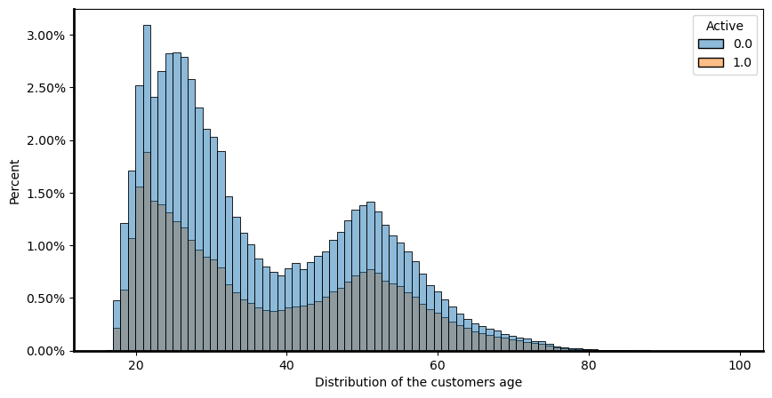

```python
fig, ax = plt.subplots(figsize=(10,5))
ax = sns.histplot(data=cust, x='age', bins=cust['age'].nunique(), hue='Active', stat="percent")
ax.set_xlabel('Distribution of the customers age')
for loc in ['bottom', 'left']:
    ax.spines[loc].set_visible(True)
    ax.spines[loc].set_linewidth(2)
    ax.spines[loc].set_color('black')
ax.yaxis.set_major_formatter(mtick.PercentFormatter())
plt.show()
```

```python
active_age_ratio = cust.groupby('age')['Active'].value_counts(normalize=True).mul(100)
active_age_ratio = active_age_ratio.rename('Active_ratio', inplace=True).reset_index()
active_age_ratio = active_age_ratio[active_age_ratio['Active']==1]
active_age_ratio['Active'] = active_age_ratio['Active'].astype(int)
active_age_ratio['age'] = active_age_ratio['age'].astype(int)
```

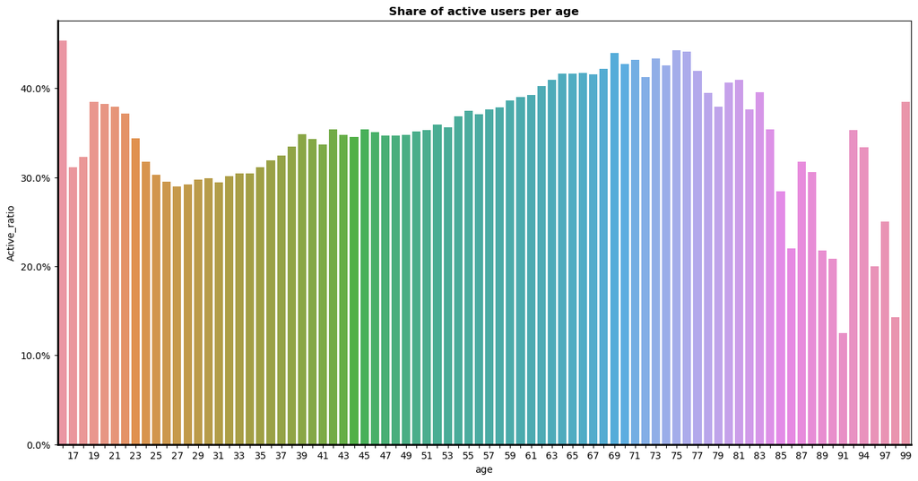

```python
fig, ax = plt.subplots(figsize=(16,8))
sns.barplot(x='age', y='Active_ratio', data=active_age_ratio)
for label in ax.xaxis.get_ticklabels()[::2]:
    label.set_visible(False)

for loc in ['bottom', 'left']:
    ax.spines[loc].set_visible(True)
    ax.spines[loc].set_linewidth(2)
    ax.spines[loc].set_color('black')
ax.yaxis.set_major_formatter(mtick.PercentFormatter())

ax.set_title("Share of active users per age", color='black', fontsize=12, weight='bold')
plt.show()
```

## Baza danych Transactions

### Jest to największa baza danych zawierająca wszystkie codzienne transakcje.

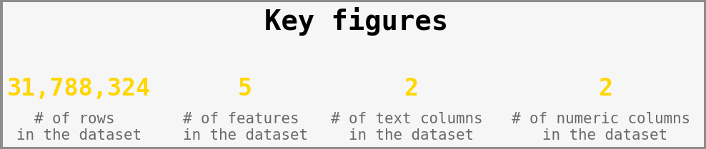

```python
mpl.rcParams.update(mpl.rcParamsDefault)

trans_dtypes = trans.dtypes.value_counts()
data = trans

fig = plt.figure(figsize=(5,2),facecolor='white')

ax0 = fig.add_subplot(1,1,1)
ax0.text(1.0, 1, "Key figures",color='black',fontsize=28, fontweight='bold', fontfamily='monospace',ha='center')

ax0.text(0, 0.4, "{:,d}".format(data.shape[0]), color='gold', fontsize=24, fontweight='bold', fontfamily='monospace', ha='center')
ax0.text(0, 0.001, "# of rows \nin the dataset",color='dimgrey',fontsize=15, fontweight='light', fontfamily='monospace',ha='center')

ax0.text(0.6, 0.4, "{}".format(data.shape[1]), color='gold', fontsize=24, fontweight='bold', fontfamily='monospace', ha='center')
ax0.text(0.6, 0.001, "# of features \nin the dataset",color='dimgrey',fontsize=15, fontweight='light', fontfamily='monospace',ha='center')

ax0.text(1.2, 0.4, "{}".format(trans_dtypes[0]), color='gold', fontsize=24, fontweight='bold', fontfamily='monospace', ha='center')
ax0.text(1.2, 0.001, "# of text columns \nin the dataset",color='dimgrey',fontsize=15, fontweight='light', fontfamily='monospace',ha='center')

ax0.text(1.9, 0.4,"{}".format(trans_dtypes[1]), color='gold', fontsize=24, fontweight='bold', fontfamily='monospace', ha='center')
ax0.text(1.9, 0.001,"# of numeric columns \nin the dataset",color='dimgrey',fontsize=15, fontweight='light', fontfamily='monospace',ha='center')

ax0.set_yticklabels('')
ax0.tick_params(axis='y',length=0)
ax0.tick_params(axis='x',length=0)
ax0.set_xticklabels('')

for direction in ['top','right','left','bottom']:
    ax0.spines[direction].set_visible(False)

fig.patch.set_linewidth(5)
fig.patch.set_edgecolor('#8c8c8c')
fig.patch.set_facecolor('#f6f6f6')
ax0.set_facecolor('#f6f6f6')

plt.show()
```

```python
trans.head()
```

|  | t_dat | customer_id | article_id | price | sales_channel_id |
| --- | --- | --- | --- | --- | --- |
| 0 | 2018-09-20 | 000058a12d5b43e67d225668fa1f8d618c13dc232df0ca... | 663713001 | 0.050831 | 2 |
| 1 | 2018-09-20 | 000058a12d5b43e67d225668fa1f8d618c13dc232df0ca... | 541518023 | 0.030492 | 2 |
| 2 | 2018-09-20 | 00007d2de826758b65a93dd24ce629ed66842531df6699... | 505221004 | 0.015237 | 2 |
| 3 | 2018-09-20 | 00007d2de826758b65a93dd24ce629ed66842531df6699... | 685687003 | 0.016932 | 2 |
| 4 | 2018-09-20 | 00007d2de826758b65a93dd24ce629ed66842531df6699... | 685687004 | 0.016932 | 2 |

```python
trans.isna().sum()
```

```
t_dat               0
customer_id         0
article_id          0
price               0
sales_channel_id    0
dtype: int64
```

### Nie ma brakujących danych. Zbadajmy kolumnę z ceną.

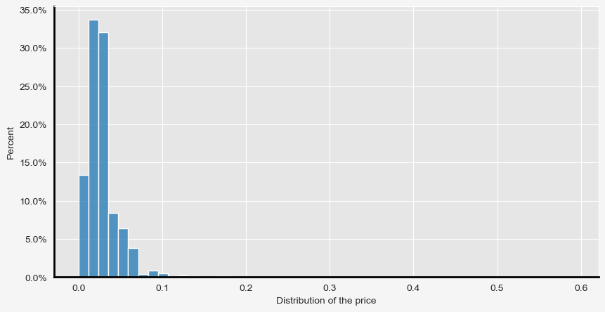

```python
sns.set_style("darkgrid", {"axes.facecolor": ".9"})
fig, ax = plt.subplots(figsize=(10,5), facecolor='#f6f5f5')
ax = sns.histplot(data=trans, x='price', bins=50, stat="percent")
ax.set_xlabel('Distribution of the price')
for loc in ['bottom', 'left']:
    ax.spines[loc].set_visible(True)
    ax.spines[loc].set_linewidth(2)
    ax.spines[loc].set_color('black')
ax.yaxis.set_major_formatter(mtick.PercentFormatter())
plt.show()
```

### Na powyższym wykresie widać wyraźnie, że mamy wiele wartości odstających. Przyjrzyjmy się cenie po obcięciu wartości powyżej 0,1.

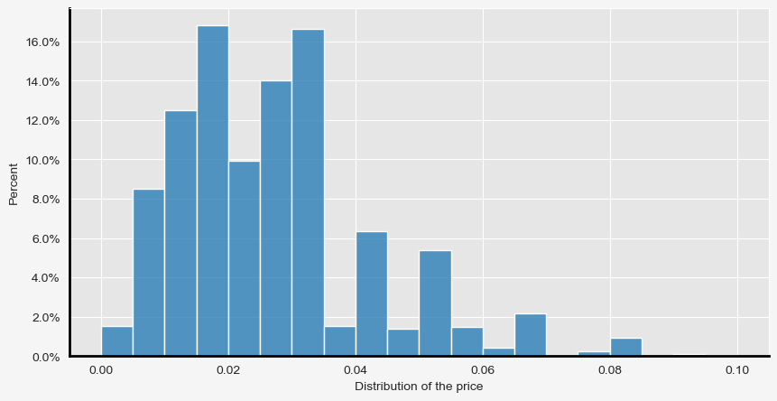

```python
fig, ax = plt.subplots(figsize=(10,5), facecolor='#f6f5f5')
data = trans[trans['price']<0.1]
ax = sns.histplot(data=data, x='price', bins=20, stat="percent")
ax.set_xlabel('Distribution of the price')
for loc in ['bottom', 'left']:
    ax.spines[loc].set_visible(True)
    ax.spines[loc].set_linewidth(2)
    ax.spines[loc].set_color('black')
ax.yaxis.set_major_formatter(mtick.PercentFormatter())
plt.show()
```

### Przyjrzyjmy się teraz rozkładowi danych w czasie. Przydatna będzie zmiana typu danych

```python
trans['t_dat'] = pd.to_datetime(trans['t_dat'])
```

```python
begin = trans['t_dat'].min()
end = trans['t_dat'].max()
print('Date range is from {} to {}.'.format(begin.date(), end.date()))
```

```
Date range is from 2018-09-20 to 2020-09-22.
```

### Dysponujemy danymi z 2 lat. Zobaczy na wykres dziennej liczby tranzakcji.

```python
t_per_day = trans.groupby('t_dat',as_index=False).count()
```

[figure not shown]

[figure not shown]

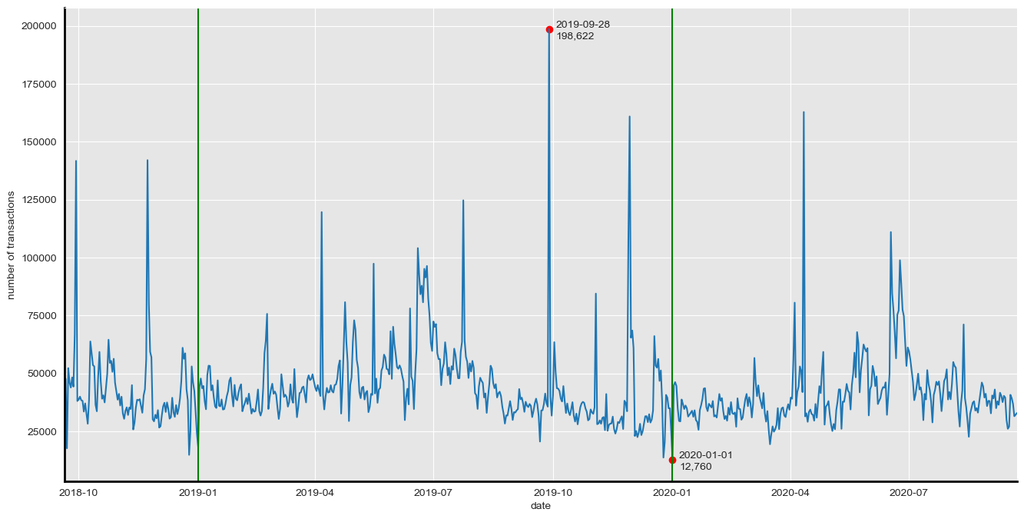

```python
fig, ax = plt.subplots(figsize=(16,8))

sns.lineplot(data=t_per_day, x='t_dat',y='customer_id')

ax.set_xlabel('date')
ax.set_ylabel('number of transactions')

ax.axvline(x=dt.datetime(2019,1,1), c='green')
ax.axvline(x=dt.datetime(2020,1,1), c='green')

max_t = t_per_day['customer_id'].max()
max_t_date = t_per_day[t_per_day['customer_id']==max_t]['t_dat']
ax.scatter(max_t_date, max_t, c='red')
ax.text(max_t_date+pd.DateOffset(days=5), max_t-4000, '{}\n{:,d}'.format(max_t_date.iloc[0].date(), max_t))

min_t = t_per_day['customer_id'].min()
min_t_date = t_per_day[t_per_day['customer_id']==min_t]['t_dat']
ax.scatter(min_t_date, min_t, c='red')
ax.text(min_t_date+pd.DateOffset(days=5), min_t-4000, '{}\n{:,d}'.format(min_t_date.iloc[0].date(), min_t))
ax.set_xlim(trans['t_dat'].min(),trans['t_dat'].max())

for loc in ['bottom', 'left']:
    ax.spines[loc].set_visible(True)
    ax.spines[loc].set_linewidth(2)
    ax.spines[loc].set_color('black')

plt.show()
```

### Na powyższym wykresie widać, że liczba transakcji w ciągu dnia jest wyraźnie zróżnicowana i gwałtownie wzrasta. Bardziej przejrzysta byłaby wizualizacja tego zjawiska za pomocą wykresów pudełkowych z agregacją miesięczną.

```python
trans_gr_month = trans.groupby('t_dat').size().rename("no_transactions")
trans_gr_month = trans_gr_month.reset_index()
trans_gr_month['month_year'] = trans_gr_month['t_dat'].dt.to_period('M')
```

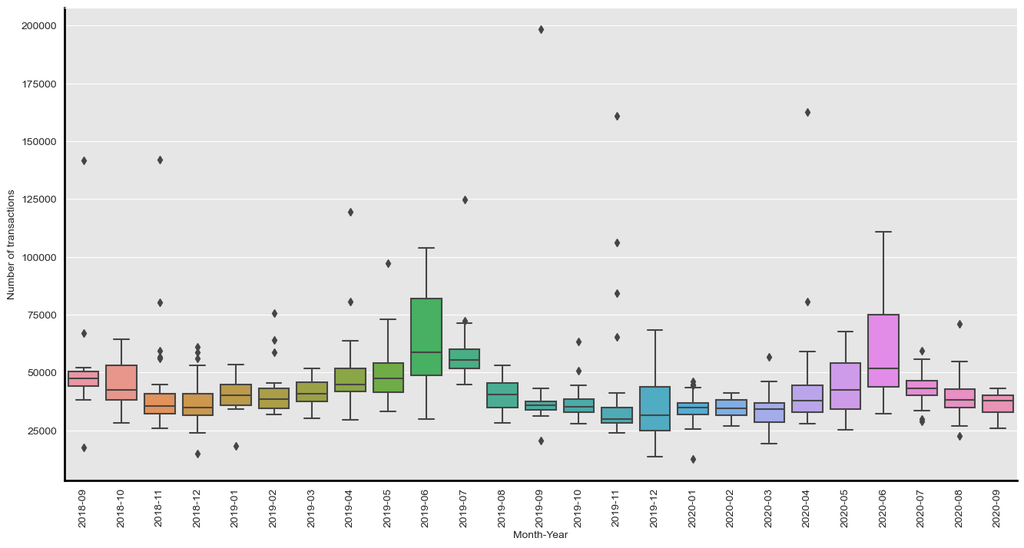

```python
fig, ax = plt.subplots(figsize=(16,8))
ax = sns.boxplot(x="month_year", y='no_transactions', data=trans_gr_month)
plt.xticks(rotation=90)
for loc in ['bottom', 'left']:
    ax.spines[loc].set_visible(True)
    ax.spines[loc].set_linewidth(2)
    ax.spines[loc].set_color('black')
ax.set_xlabel('Month-Year')
ax.set_ylabel('Number of transactions')
plt.show()
```

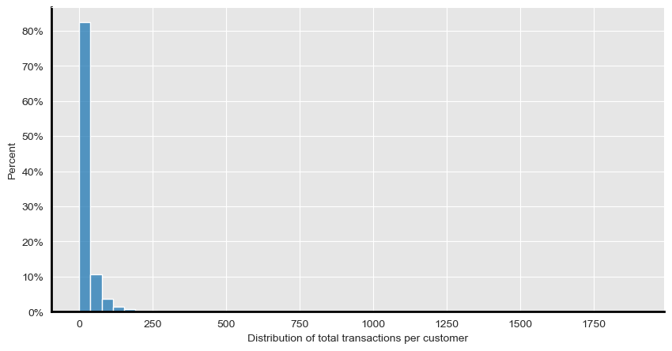

```python
t_by_customer = trans.groupby('customer_id', as_index=False).size()

fig, ax = plt.subplots(figsize=(10,5))
ax = sns.histplot(data=t_by_customer, x='size', bins=50, stat="percent")
ax.set_xlabel('Distribution of total transactions per customer')
for loc in ['bottom', 'left']:
    ax.spines[loc].set_visible(True)
    ax.spines[loc].set_linewidth(2)
    ax.spines[loc].set_color('black')
ax.yaxis.set_major_formatter(mtick.PercentFormatter())
plt.show()
```

### Najwyraźniej jest tam wiele wartości odstających. Przyjrzyjmy się rozkładowi po wycięciu wszystkiego, co przekracza 50 transakcji na klienta.

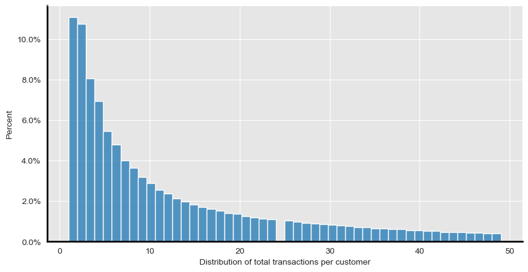

```python
t_by_customer_50tr = t_by_customer[t_by_customer['size'] < 50]

fig, ax = plt.subplots(figsize=(10,5))
ax = sns.histplot(data=t_by_customer_50tr, x='size', bins=50, stat="percent")
ax.set_xlabel('Distribution of total transactions per customer')
for loc in ['bottom', 'left']:
    ax.spines[loc].set_visible(True)
    ax.spines[loc].set_linewidth(2)
    ax.spines[loc].set_color('black')
ax.yaxis.set_major_formatter(mtick.PercentFormatter())
plt.show()
```

### Powyższy wykres pokazuje, że w ciągu tych dwóch lat większość klientów kupiła średnio tylko kilka artykułów.Przyjrzyjmy się teraz popularności kanałów sprzedaży.

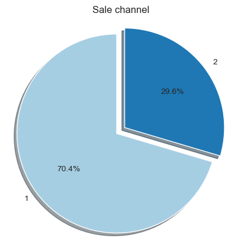

```python
fig, ax = plt.subplots(figsize=(5,5))
explode = (0, 0.1)
colors = sns.color_palette('Paired')
ax.pie(trans['sales_channel_id'].value_counts(), explode=explode, labels=['1','2'],
       autopct='%1.1f%%',shadow=True, startangle=90, colors=colors)
ax.axis('equal')
ax.set_title('Sale channel')
plt.show()
```